# BEM_RightingResponse

Kevin Mack

2/18/2016

## Preliminary Analysis

This is preliminary/exploratory analysis of sublethal righting responses of *P. armatus*. I ran an ANCOVA and on the main effects: site, sex, and block with crab size (CW) as a covariate. A significant block effect was detected. This prelimary analysis indicates that the covariate CW was the strongest effect, however CW is closely linked to crab sex, with males generally being larger than females. There were no significant interactions. This analysis informed the analysis of main effects conducted next.

```r
KM_Righting <- read.csv("~/Applied Quant Project/Righting-Response/Trial1_sublethal.csv")
KM_Righting$Block=as.factor(KM_Righting$Block)
library(survival)

#ANCOVA of main effests: Righting Response
options(contrasts=c("contr.sum", "contr.poly"))
fit1=(aov(lm(Duration~Site*Sex*Block+CW, data=KM_Righting)))
drop1(fit1,~.,test='F')
```

```
## Single term deletions
##
## Model:
## Duration ~ Site * Sex * Block + CW
##                Df Sum of Sq   RSS    AIC F value    Pr(>F)
## <none>                      80859 1561.8
## Site            7    2774.7 83634 1556.4  1.0050 0.4288275
## Sex             1    1599.4 82458 1564.8  4.0548 0.0453523 *
## Block           2    6245.6 87104 1576.7  7.9172 0.0004875 ***
## CW              1    6130.1 86989 1578.4 15.5415 0.0001107 ***
## Site:Sex        7    1791.1 82650 1553.4  0.6487 0.7152026
## Site:Block     14    2792.7 83652 1542.5  0.5057 0.9282565
## Sex:Block       2    1568.3 82427 1562.7  1.9881 0.1395916
## Site:Sex:Block 14    2408.0 83267 1541.3  0.4361 0.9614621
## ---
## Signif. codes:  0 '***' 0.001 '**' 0.01 '*' 0.05 '.' 0.1 ' ' 1
```

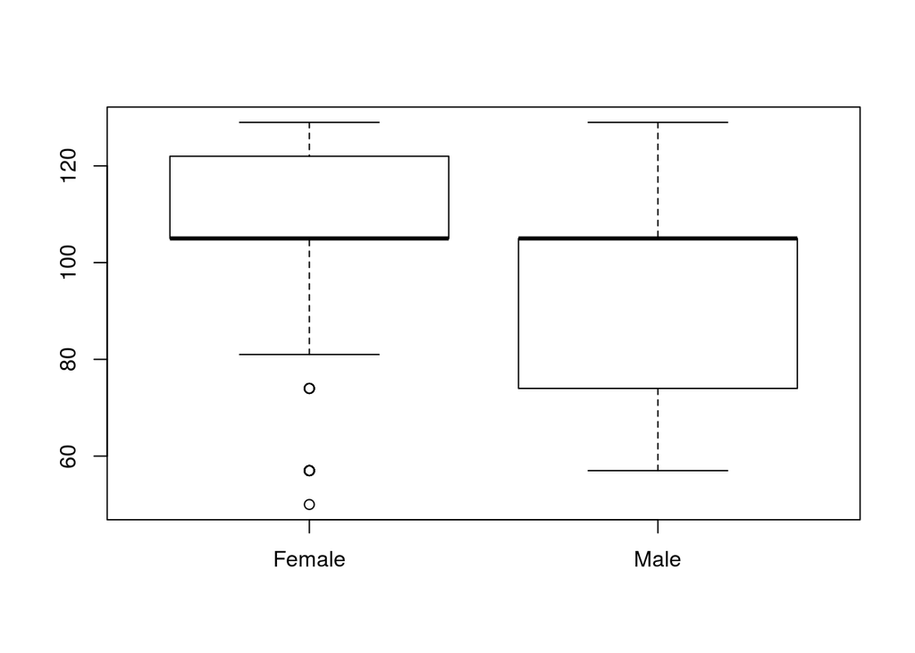

```r
#Boxplots: Righting Response
plot(KM_Righting$Sex, KM_Righting$Duration)
```

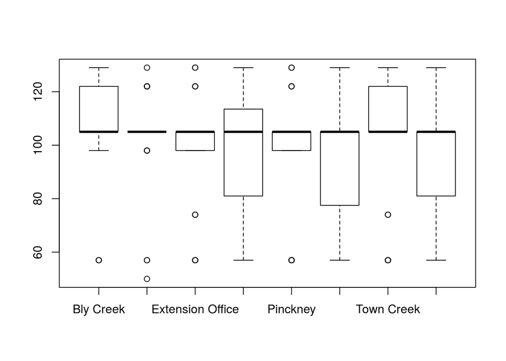

```r
plot(KM_Righting$Site, KM_Righting$Duration)
```

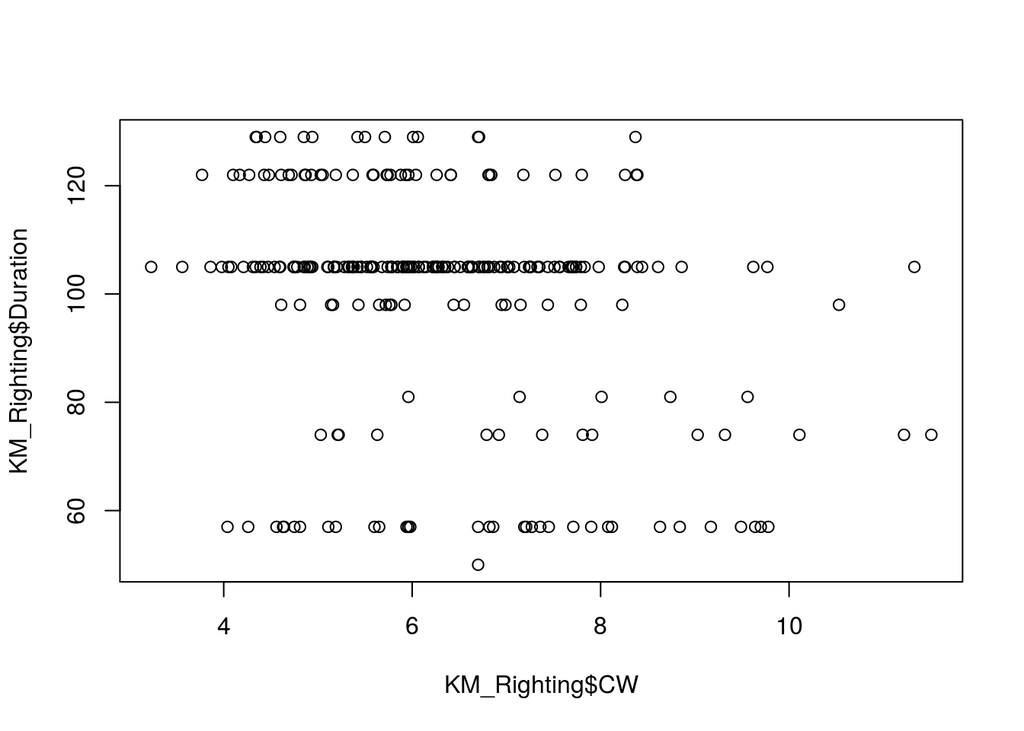

```r
plot(KM_Righting$CW,KM_Righting$Duration)
```

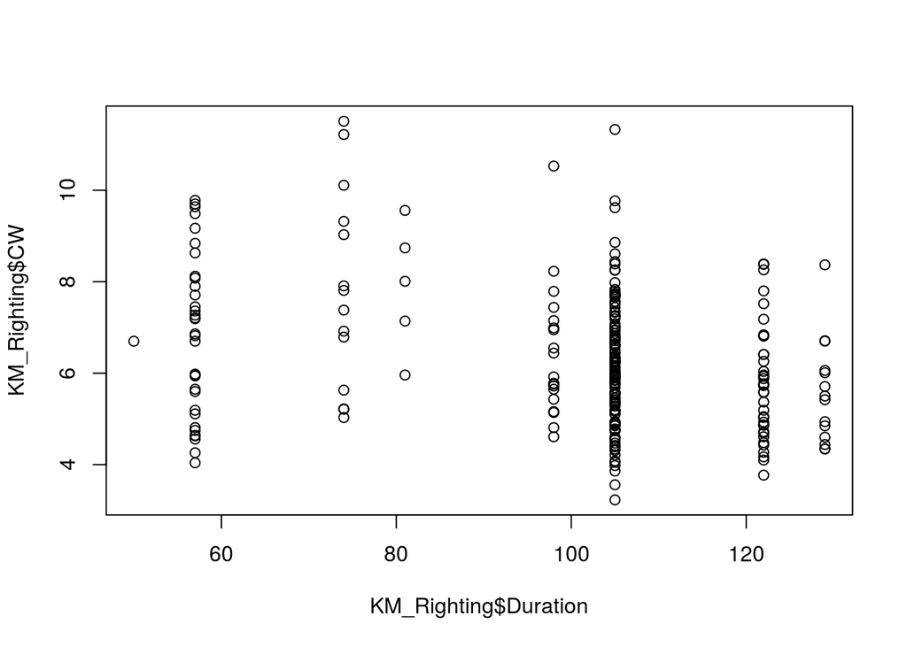

```r
plot(KM_Righting$Duration, KM_Righting$CW )
```

```r
#closley related to sex. Examine males and females separetely?
```

## Analysis of Main Effects

This is analysis of righting responses of *P. armatus*. I tested the main effects: site, sex, block and crab size (CW) by generating Kaplan-Meier curves for righting response data, main effects were tested with a Log Rank test. I next fitted these curves to a Cox proportional hazards model to determine differences in hazard risk between main effects. No significant differences were found between sites, but were detected between sexes and sizes. This helped me determine how to present differences between my main effects.

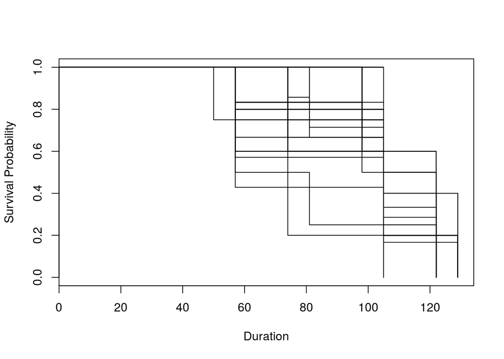

```r
#KM Curves of main effects
rr_mod1=survfit(Surv(Duration,Status)~Block+Site+Sex, data=KM_Righting)
plot(rr_mod1, ylab='Survival Probability', xlab='Duration')
```

```r
#Log Rank test of main effects tests for differences
rr_mod1_dif=survdiff(Surv(Duration,Status)~Block+Site+Sex, data=KM_Righting)
rr_mod1_dif
```

```
## Call:
## survdiff(formula = Surv(Duration, Status) ~ Block + Site + Sex,
##     data = KM_Righting)
##
##                                            N Observed Expected (O-E)^2/E
## Block=1, Site=Bly Creek       , Sex=Female 5        5     6.65  4.10e-01
## Block=1, Site=Bly Creek       , Sex=Male   5        5     4.48  6.01e-02
## Block=1, Site=Bowens Island   , Sex=Female 5        5     5.92  1.44e-01
## Block=1, Site=Bowens Island   , Sex=Male   5        5     5.21  8.20e-03
## Block=1, Site=Extension Office, Sex=Female 5        5     5.09  1.50e-03
## Block=1, Site=Extension Office, Sex=Male   5        5     4.49  5.83e-02
## Block=1, Site=Grice           , Sex=Female 5        5     5.84  1.20e-01
## Block=1, Site=Grice           , Sex=Male   4        4     4.77  1.25e-01
## Block=1, Site=Pinckney        , Sex=Female 4        4     4.16  6.12e-03
## Block=1, Site=Pinckney        , Sex=Male   5        5     5.49  4.35e-02
## Block=1, Site=Roebling House  , Sex=Female 8        8     8.33  1.33e-02
## Block=1, Site=Roebling House  , Sex=Male   6        6     6.34  1.81e-02
## Block=1, Site=Town Creek      , Sex=Female 5        5     7.38  7.65e-01
## Block=1, Site=Town Creek      , Sex=Male   5        5     8.54  1.47e+00
## Block=1, Site=Trask           , Sex=Female 6        6     5.34  8.03e-02
## Block=1, Site=Trask           , Sex=Male   7        7     7.08  8.87e-04
## Block=2, Site=Bly Creek       , Sex=Female 5        5     6.93  5.39e-01
## Block=2, Site=Bly Creek       , Sex=Male   5        5     7.03  5.86e-01
## Block=2, Site=Bowens Island   , Sex=Female 4        4     3.86  5.35e-03
## Block=2, Site=Bowens Island   , Sex=Male   5        5     4.30  1.15e-01
## Block=2, Site=Extension Office, Sex=Female 5        5     6.93  5.39e-01
## Block=2, Site=Extension Office, Sex=Male   6        6     4.50  5.00e-01
## Block=2, Site=Grice           , Sex=Female 5        5     6.75  4.53e-01
## Block=2, Site=Grice           , Sex=Male   4        4     1.54  3.91e+00
## Block=2, Site=Pinckney        , Sex=Female 6        6     8.70  8.37e-01
## Block=2, Site=Pinckney        , Sex=Male   7        7     4.57  1.29e+00
## Block=2, Site=Roebling House  , Sex=Female 6        6     4.62  4.13e-01
## Block=2, Site=Roebling House  , Sex=Male   6        6     5.23  1.15e-01
## Block=2, Site=Town Creek      , Sex=Female 6        6     6.89  1.14e-01
## Block=2, Site=Town Creek      , Sex=Male   5        5     4.30  1.15e-01
## Block=2, Site=Trask           , Sex=Female 4        4     3.44  9.07e-02
## Block=2, Site=Trask           , Sex=Male   5        5     4.19  1.58e-01
## Block=3, Site=Bly Creek       , Sex=Female 4        4     3.98  6.89e-05
## Block=3, Site=Bly Creek       , Sex=Male   6        6     5.34  8.03e-02
## Block=3, Site=Bowens Island   , Sex=Female 5        5     6.92  5.35e-01
```

[output cut: 49 more lines]

```
## Block=3, Site=Bowens Island   , Sex=Male    0.234449
## Block=3, Site=Extension Office, Sex=Female  0.046959
## Block=3, Site=Extension Office, Sex=Male    1.126118
## Block=3, Site=Grice           , Sex=Female  0.000241
## Block=3, Site=Grice           , Sex=Male    0.192708
## Block=3, Site=Pinckney        , Sex=Female  0.327495
## Block=3, Site=Pinckney        , Sex=Male    5.747465
## Block=3, Site=Roebling House  , Sex=Female  0.280005
## Block=3, Site=Roebling House  , Sex=Male    9.939417
## Block=3, Site=Town Creek      , Sex=Female  0.000241
## Block=3, Site=Town Creek      , Sex=Male    0.339476
## Block=3, Site=Trask           , Sex=Female  1.009148
## Block=3, Site=Trask           , Sex=Male    0.007823
##
##  Chisq= 51.2  on 47 degrees of freedom, p= 0.311
```

```r
#Cox proportional hazards model fit
rr_mod1_cox=coxph(Surv(Duration,Status)~Block+Site+Sex+CW, data=KM_Righting)
summary(rr_mod1_cox)
```

```
## Call:
## coxph(formula = Surv(Duration, Status) ~ Block + Site + Sex +
##     CW, data = KM_Righting)
##
##   n= 254, number of events= 254
##
##             coef exp(coef)  se(coef)      z Pr(>|z|)
## Block1 -0.136440  0.872458  0.090690 -1.504   0.1325
## Block2 -0.060693  0.941112  0.090799 -0.668   0.5039
## Site1  -0.320134  0.726052  0.174502 -1.835   0.0666 .
## Site2   0.039816  1.040619  0.174918  0.228   0.8199
## Site3   0.101438  1.106761  0.164449  0.617   0.5373
## Site4   0.005809  1.005826  0.176227  0.033   0.9737
## Site5   0.087957  1.091941  0.161893  0.543   0.5869
## Site6   0.276355  1.318316  0.159848  1.729   0.0838 .
## Site7  -0.324210  0.723098  0.170123 -1.906   0.0567 .
## Sex1   -0.083432  0.919953  0.066159 -1.261   0.2073
## CW      0.204820  1.227305  0.046842  4.373 1.23e-05 ***
## ---
## Signif. codes:  0 '***' 0.001 '**' 0.01 '*' 0.05 '.' 0.1 ' ' 1
##
##        exp(coef) exp(-coef) lower .95 upper .95
## Block1    0.8725     1.1462    0.7304     1.042
## Block2    0.9411     1.0626    0.7877     1.124
## Site1     0.7261     1.3773    0.5157     1.022
## Site2     1.0406     0.9610    0.7386     1.466
## Site3     1.1068     0.9035    0.8018     1.528
## Site4     1.0058     0.9942    0.7121     1.421
## Site5     1.0919     0.9158    0.7951     1.500
## Site6     1.3183     0.7585    0.9637     1.803
## Site7     0.7231     1.3829    0.5181     1.009
## Sex1      0.9200     1.0870    0.8081     1.047
## CW        1.2273     0.8148    1.1196     1.345
##
## Concordance= 0.673  (se = 0.037 )
## Rsquare= 0.123   (max possible= 1 )
## Likelihood ratio test= 33.3  on 11 df,   p=0.0004695
## Wald test            = 33.92  on 11 df,   p=0.0003723
## Score (logrank) test = 34.55  on 11 df,   p=0.0002936
```

```r
#ANOVA of main effects, Useful for checking results
anova(rr_mod1_cox)
```

```
## Analysis of Deviance Table
##  Cox model: response is Surv(Duration, Status)
## Terms added sequentially (first to last)
##
##        loglik   Chisq Df Pr(>|Chi|)
## NULL  -1156.2
## Block -1154.0  4.3038  2    0.11627
## Site  -1151.2  5.6608  7    0.57986
## Sex   -1148.7  4.9321  1    0.02636 *
## CW    -1139.5 18.4083  1  1.783e-05 ***
## ---
## Signif. codes:  0 '***' 0.001 '**' 0.01 '*' 0.05 '.' 0.1 ' ' 1
```